# Nanopore reads spanning the entire genome of nuclear arthropod-specific large DNA viruses

Jörg Wennmann

2024-10-06

# Introduction

Nanopore sequencing is becoming increasingly popular for sequencing the genomes of nuclear arthropod-specific large DNA viruses (NALDV). In particular, in combination with Illumina sequencing, it provides a highly accurate method for error-free decoding of large repetitive sequence regions. As of July 2024, hundreds of genomes in the Naldaviricetes class have been published in the NCBI Genbank. These are consensus sequences based on assemblies. Nanopore sequencing makes it possible for the first time to sequence significantly large fragments of NALDV genomes. It is even conceivable that entire genomes could be sequenced in single reads, enabling assembly-free analysis of baculovirus genomes.

The following script shows how to approach nanopore sequence data sets of NALDVs step by step. It demonstrates the importance of carefully examining the data to avoid subsequent errors in the analysis.

Particular attention is paid to the detection of reads that may comprise entire genomes of NALDVs and represent individual viral genomes.

# Required libraries

The following libraries are required to run this script.

```r
library(xml2)
library(XML)
library(ggplot2)
library(patchwork)
library(RColorBrewer)
`%ni%` <- Negate(`%in%`)
```

# Consensus genomes published on NCBI Genbank

To get an overview of the number of published NALDV genomes (as of July 2024), all NCBI Genbank entries found under the individual names of the virus families (Baculoviridae, Nudiviridae, Nimaviridae, Hytrosaviridae) are available in the directory /data/xml. A filter has been set to only allow sequences in the range of complete genomes. The list is probably not complete, but it is a good approximation of all genomes that are publicly available at this time.

The XML files are first read into R and converted into a data frame. The virus name (isolate, strain), accession number, genome length and publication date are extracted.

## Function to read and process XML files

A function is needed to read the NCBI Genbank XML files. This is provided below. However, the XML files are very large and therefore not included in this Github repository. Instead, only one file (for the virus family Hytrosaviridae) was provided. Instead, the output for all XML, a CSV file, was added to the Github repository. This is imported below so that the entire data set can be further processed.

```r
process_virus_family <- function(file_path, family_name, must_be_in_name = NULL, alpha_terms = NULL, beta_terms = NULL) {

  # Read the XML file
  xml_file <- read_xml(file_path)

  # Find all INSDSeq nodes
  insdseq_nodes <- xml_find_all(xml_file, "//INSDSeq")

  # Extract relevant information
  accession_numbers <- xml_text(xml_find_all(insdseq_nodes, ".//INSDSeq_locus"))
  create_dates <- xml_text(xml_find_all(insdseq_nodes, ".//INSDSeq_create-date"))
  source_org <- xml_text(xml_find_all(insdseq_nodes, ".//INSDSeq_source"))
  genome_length <- xml_text(xml_find_all(insdseq_nodes, ".//INSDSeq_length"))

  # Create DataFrame
  df <- data.frame(AccessionNumber = accession_numbers,
                   Length = genome_length,
                   CreateDate = create_dates,
                   Source = source_org,
                   stringsAsFactors = FALSE)

  # If a filter for specific terms in must_be_in_name exists
  if (!is.null(must_be_in_name)) {
    matches <- sapply(must_be_in_name, grepl, df$Source)
    keep_indices <- apply(matches, 1, any)
    df <- df[keep_indices, ]
  }

  # Add column for category, if alpha and beta terms are provided
  df$Category <- NA

  if (!is.null(alpha_terms)) {
    for (word in alpha_terms) {
      df$Category[grepl(word, df$Source, ignore.case = TRUE)] <- "alpha, gamma and delta"
    }
  }

  if (!is.null(beta_terms)) {
    for (word in beta_terms) {
      df$Category[grepl(word, df$Source, ignore.case = TRUE)] <- "beta"
    }
  }

  # Add family tag
  df$Family <- family_name

  return(df)
}
```

## Importing the entire genome data set from a CSV file

The code below creates a DataFrame from provided XML files (available from NCBI GenBank) that extracts the names of virus genomes, their lengths and the date of publication. However, since the XML files are too large to include in this GitHub repository, the code first checks whether the XML files have already been processed and saved as a CSV file. Since this is the case, the existing CSV file that is attached to the repository is read and used.

```r
# path to file
file_path <- "output/genome_genbank_table/xml_imported_virus_data.csv"

# test if file is already present
if (file.exists(file_path)) {

  # CSV file exists; read CSV
  df <- read.csv(file_path, stringsAsFactors = FALSE)
  # Create the specific dataframe per virus family
  dfBAC <- df[df$Family == "Baculoviridae", ]
  dfNimV <- df[df$Family == "Nimaviridae", ]
  dfNV <- df[df$Family == "Nudiviridae", ]
  dfHV <- df[df$Family == "Hytrosaviridae", ]

} else {

  # Read Baculoviridae data
  dfBAC <- process_virus_family(
    file_path = "data/xml/Baculoviridae_ncbi_genbank_entry.xml",
    family_name = "Baculoviridae",
    must_be_in_name = c("nucleopolyhedrovirus",
                        "granulovirus",
                        "SNPV",
                        "nuclopolyhedrovirus",
                        "Alphabaculovirus",
                        "Betabaculovirus",
                        "betabaculovirus",
                        "NPV",
                        "nucleopolyhedrosis",
                        "alphabaculovirus"),
    alpha_terms = c("nucleopolyhedrovirus",
                    "SNPV",
                    "nuclopolyhedrovirus",
                    "Alphabaculovirus",
                    "NPV",
                    "nucleopolyhedrosis",
                    "alphabaculovirus"),
    beta_terms = c("granulovirus",
                   "Betabaculovirus",
                   "betabaculovirus")
  )


  # Read Nudiviridae data
  dfNV <- process_virus_family(
    file_path = "data/xml/Nudiviridae_ncbi_genbank_entry.xml",
    family_name = "Nudiviridae"
  )


  # Read Hytrosaviridae data
  dfHV <- process_virus_family(
    file_path = "data/xml/Hytrosaviridae_ncbi_genbank_entry.xml",
    family_name = "Hytrosaviridae"
  )


  # Read Nimaviridae data
  dfNimV <- process_virus_family(
    file_path = "data/xml/Nimaviridae_ncbi_genbank_entry.xml",
    family_name = "Nimaviridae"
  )


  df <- rbind(dfNV, dfBAC, dfHV, dfNimV)

  #export zu CSV file
  write.csv(df, file = file_path, row.names = FALSE)

}

print(head(df))
```

```
##   AccessionNumber Length  CreateDate                        Source Category
## 1        PP539711 147048 20-APR-2024   Faxonius rusticus nudivirus     <NA>
## 2        PP539710 144948 20-APR-2024    Faxonius virilis nudivirus     <NA>
## 3        PP539709 130164 20-APR-2024 Faxonius propinquus nudivirus     <NA>
## 4        OQ725696  99336 13-NOV-2023  Menippe mercenaria nudivirus     <NA>
## 5        OR596894 129467 28-OCT-2023      Apis mellifera nudivirus     <NA>
## 6        BK063656 126408 24-AUG-2023  Oryctes rhinoceros nudivirus     <NA>
##        Family
## 1 Nudiviridae
## 2 Nudiviridae
## 3 Nudiviridae
## 4 Nudiviridae
## 5 Nudiviridae
## 6 Nudiviridae
```

## Visualisation of genome publications over time

After the data frame has been created, the time course of the publication of the consensus sequences can be displayed with ggplot2.

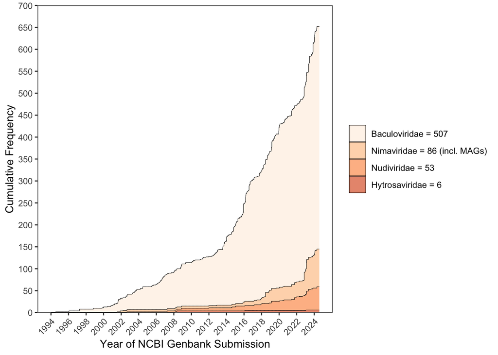

```r
# Umwandlung der CreateDate-Spalte in ein Date-Objekt
df$CreateDate <- as.Date(df$CreateDate, format = "%d-%b-%Y")

# Filter auf die gewünschten Daten
df <- df[df$CreateDate <= as.Date("2024-07-30"), ]

# Berechnung der kumulativen Häufigkeit für jede Familie
families <- unique(df$Family)
cumulative_values <- list()

for (family in families) {
  family_data <- df[df$Family == family, ]
  family_data <- family_data[order(family_data$CreateDate), ]
  family_data$Value <- 1
  family_data$CumulativeValue <- cumsum(family_data$Value)

  # Sicherstellen, dass alle Familien am 30.07.2024 enden
  full_dates <- seq.Date(from = as.Date("1994-01-01"), to = as.Date("2024-07-30"), by = "day")
  complete_data <- merge(data.frame(CreateDate = full_dates), family_data, by = "CreateDate", all.x = TRUE)
  complete_data$Family <- family
  complete_data$Value[is.na(complete_data$Value)] <- 0
  complete_data$CumulativeValue <- cumsum(complete_data$Value)

  cumulative_values[[family]] <- complete_data
}

df_complete <- do.call(rbind, cumulative_values)

df_complete$Family <- factor(df_complete$Family, levels = c("Baculoviridae", "Nimaviridae", "Nudiviridae", "Hytrosaviridae"))

#----------PLOT------------

colorPalette <- "Oranges"

date_breaks <- seq(as.Date("1994-01-01"), as.Date("2024-07-30"), by = "2 years")

pGB <- ggplot(df_complete, aes(x = CreateDate, y = CumulativeValue,
                               fill = Family, group = Family)) +
  geom_area(colour = "black",
            #position = "identity",
            linewidth = 0.2, alpha = 0.6) +
  scale_fill_manual(values = c("Baculoviridae" = brewer.pal(4, colorPalette)[1],
                               "Nimaviridae" = brewer.pal(4, colorPalette)[2],
                               "Nudiviridae" = brewer.pal(4, colorPalette)[3],
                               "Hytrosaviridae" = brewer.pal(4, colorPalette)[4]),

                    labels = c(paste("Baculoviridae = ", dim(dfBAC)[1], sep = ""),
                               paste("Nimaviridae = ", dim(dfNimV)[1],
                                     " (incl. MAGs)", sep = ""),
                               paste("Nudiviridae = ", dim(dfNV)[1], sep = ""),
                               paste("Hytrosaviridae = ", dim(dfHV)[1], sep = ""))) +
  theme_bw() +
  scale_x_date(breaks = date_breaks, date_labels = "%Y",
               limits = as.Date(c("1994-01-01", max(df_complete$CreateDate)))) +
  scale_y_continuous(expand = c(0, 0),
                     limits = c(0, 700),
                     breaks = seq(0, 700, by = 50)) +
  theme(panel.grid.major = element_blank(),
        panel.grid.minor = element_blank(),
        legend.position.inside  = c(0.4, 0.7),
        legend.title = element_blank(),
        axis.text.x = element_text(angle = 45, vjust = 1, hjust = 1)) +
  ylab("Cumulative Frequency") +
  xlab("Year of NCBI Genbank Submission")

print(pGB)
```

# Sequence data available from NCBI SRA